# Marine protected area analyst using EMIS/GMIS

Laurent Dubroca

2014-12-04

The vignette illustrates the use of the EMISR package to analyse data for a marine protected area (MPA).

# Choose your mpa

The SpatialPolygonsDataFrames `mpa1` and `mpa2` contain the marine protected areas of the world. To select one MPA:

```r
 wdpaid<-555540558
 mpa<-mpa2[mpa2@data$wdpaid==wdpaid,]
 proj4string(mpa)<-CRS("+proj=longlat +datum=WGS84")
```

Then plot it:

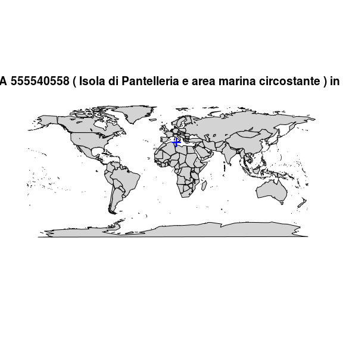

```r
 #build a terrestrial polygon around the mpa
 mappoly<-map("worldHires",fill=T,plot=FALSE,xlim=c(extent(mpa)@xmin-1,extent(mpa)@xmax+1),ylim=c(extent(mpa)@ymin-1,extent(mpa)@ymax+1))
 IDs <- sapply(strsplit(mappoly$names, ":"), function(x) x[1])
 coast<- map2SpatialPolygons(mappoly, IDs=IDs, proj4string=CRS("+proj=longlat +datum=WGS84"))
 #plot at global scale
 map("worldHires",col="light grey",fill=T)
 points(coordinates(mpa),cex=2,col="blue",pch="+")
 title(paste("MPA",mpa@data$wdpaid,"(",mpa@data$name,")","in",mpa@data$country),cex=.5)
```

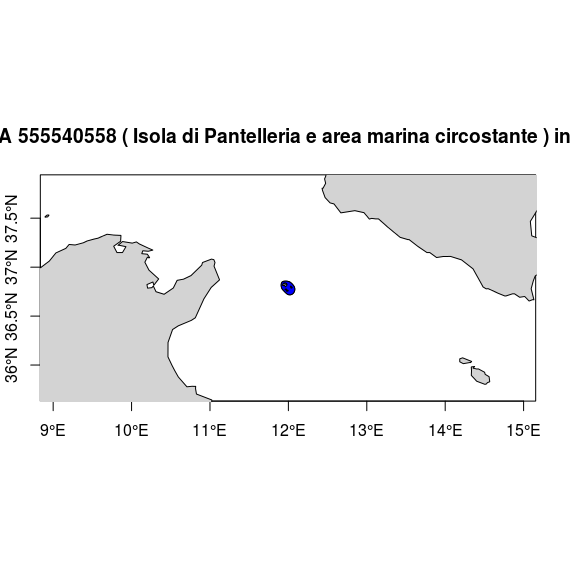

```r
 #local plot
 plot(mpa,xlim=c(extent(mpa)@xmin-1,extent(mpa)@xmax+1),ylim=c(extent(mpa)@ymin-1,extent(mpa)@ymax+1),axes=T,col="red")
 map("worldHires",add=T,col="light grey",fill=T)
 plot(mpa,add=T,col="blue")
 title(paste("MPA",mpa@data$wdpaid,"(",mpa@data$name,")","in",mpa@data$country),cex=.5)
```

# Environmental parameters extraction and analysis

The function `mpaextract` download the requested parameter on EMIS (european waters, high spatial resolution) or GMIS (global scale, but only available at 4 and 9 km).

```r
#extraction of the MODIS sea surface temperature at 2 km between 2009 and 2012 on the Pantelleria marine protected area (Italy)
pantelleria_sst<-mpaextract("EMIS_T_SST","2km","2009-01","2012-12",555540558)
#extraction of the MODIS sea surface temperature at 2 km between 2009 and 2012 on the Pantelleria marine protected area (Italy)
pantelleria_chl<-mpaextract("EMIS_A_CHLA","2km","2009-01","2012-12",555540558)
```

Then the extracted parameters can be processed in two ways:

- graphically, some figures are elaborated (plot of the whole series, average, climatology and boxplot of the climatology). The function `mpaprocessplt` does this graphical processing.

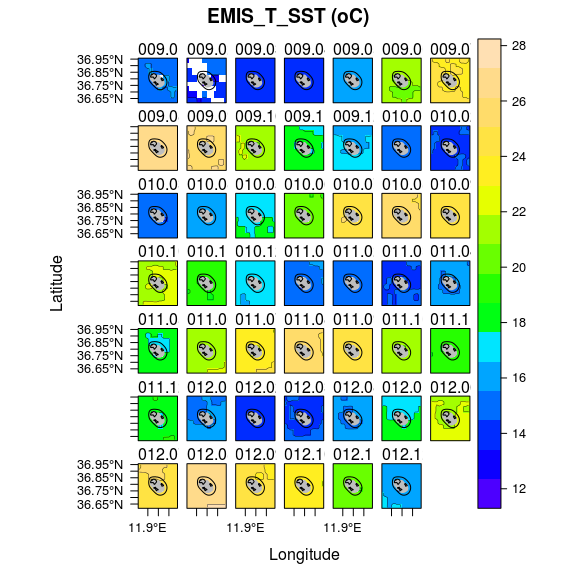

```r
plt<-mpaprocessplot(imgs=pantelleria_sst,mpa=pantelleria_mpa,name="EMIS_T_SST",unite="oC",logscale=FALSE)
#map of the whole series
plt[[1]]+latticeExtra::layer(sp.polygons(coast,fill="grey",col="grey"))+latticeExtra::layer(sp.polygons(pantelleria_mpa))
```

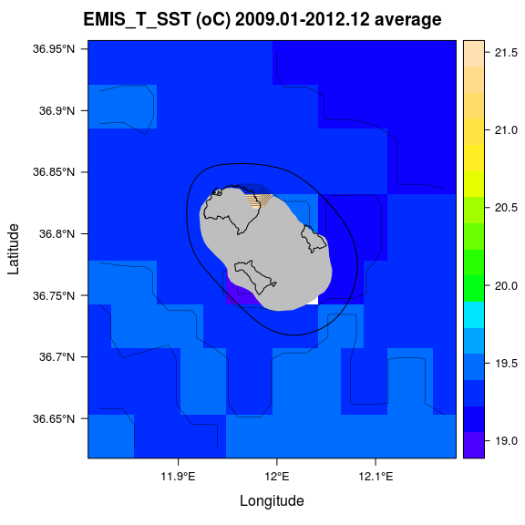

```r
#map of the average SST
plt[[2]]+latticeExtra::layer(sp.polygons(coast,fill="grey",col="grey"))+latticeExtra::layer(sp.polygons(pantelleria_mpa))
```

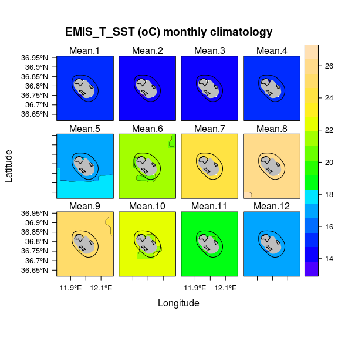

```r
#map of the climatology
plt[[3]]+latticeExtra::layer(sp.polygons(coast,fill="grey",col="grey"))+latticeExtra::layer(sp.polygons(pantelleria_mpa))
```

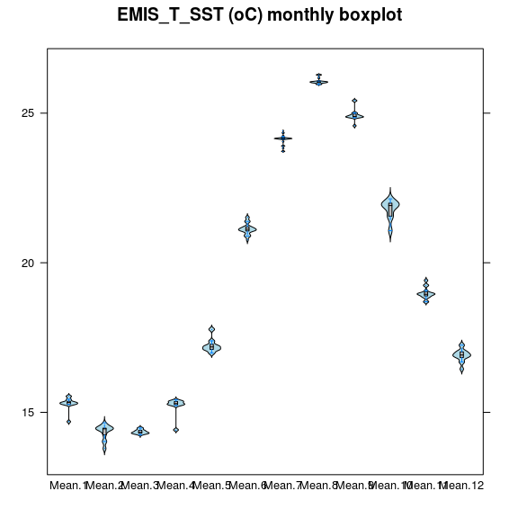

```r
#boxplot of the climatology
plt[[4]]
```

- summary statistics for the parameter are computed thanks to the `mpaprocessstat` function. See the help of this function for the details of the statistical analysis done. A graphic with the time series decomposition of the parameter values averaged on the MPA area is given.

```r
datstat<-mpaprocessstat(imgs=pantelleria_sst,mpa=pantelleria_mpa,name="EMIS_T_SST",unite="oC")
#the statistics
datstat[[1]]
```

```
#>         name unite       timerange pixelnb fracnbna fractsna  mean    sd
#> 1 EMIS_T_SST    oC 2009.01/2012.12      38    17.21        0 19.38 4.175
#>     min   max varseason vartrend trendtest sen.slope
#> 1 12.34 26.99     97.58   0.3606 1.286e-23    0.2144
```

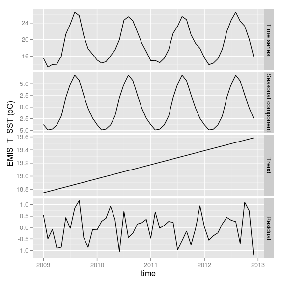

```r
#time series decomposition
datstat[[2]]
```

-the function `mpaprocess` calls successively the functions `mpaextract`,`mpaprocessplt` and `mpaprocessstat` and gives all the outputs (plot and statistics) in a list.

```r
pltstat<-mpaprocess(name = "EMIS_A_CHLA", resolution = "4km", startdate = "2009-01", enddate = "2012-12", wdpaid = 555540558)
```

Results can be combine with more than one parameters repeating extraction and analysis changing the name of the parameters.